# Impakti i thatesirave ne ekosisteme

Desard Poka , Klauberta Morina

## Hyrje

1.Pse eshte e rendesishme te studjojme impaktin qe ka thatesia?

2.Nje pamje me e qarte nder vite.

3.Qellimi final i projektit.

Thatsirat mjedisore jane nje nga faktoret te cilet sfidojne boten e sotme duke shkaktuar deme mjaft te medha ne ekosisteme si dhe deme ekonomike etj. Thatesia eshte nje pjese normale e natyres ne disa vende te botes e cila ndodh nag rreshjet e pakta te nje periudhe te gjate kohore , kjo gje sjell(ne periudha te perzgjatura) , uljen e nivelit te ujrave siperfaqesore te cilet prekin negativisht agrikulturen , ecosistemet si dhe bio-diversitetin ne natyre . Periudha te perzgjatura thatesia shkaktojne renie ne gjelberim total apo pyjeve , varferim te dheut ,rritje te zjarreve dhe ulje te gjallesave totale ne nje zone te caktuar .

## Qellimi i projektit

Ky projekt ka qellim te analizoje se si thatesia ka goditur ekosistemet Europiane ne 20 vitet e fundit.

Duke perdorur nje dataset nga Agjensia Europiane e Mjedisit ose (EEA),ne do te shikojme pak nga afer zgjerimin e kete fenmeni gjithnje e me te pranishem ne europe nga viti 2000-2023.

## Dataseti

1.Periudha 2000-2023

2.Njesia $km^2$

## Kolonat:

```r
library(tidyverse)
```

```r
library(ggplot2)
library(knitr)
library(esquisse)
library(dplyr)
library(plotly)
library(e1071)
data <- read_csv("eea_s_eu-sdg-15-42_p_2000-2023_v02_r00.csv")
head(data)
```

```
## # A tibble: 6 × 10
##   eu_sdg dimension dimension_label     unit  unit_label    geo   geo_label  time
##   <chr>  <chr>     <chr>               <chr> <chr>         <chr> <chr>     <dbl>
## 1 15_42  KM2       Drought impact area KM2   Square kilom… EU27… European…  2000
## 2 15_42  KM2       Drought impact area KM2   Square kilom… EU27… European…  2001
## 3 15_42  KM2       Drought impact area KM2   Square kilom… EU27… European…  2002
## 4 15_42  KM2       Drought impact area KM2   Square kilom… EU27… European…  2003
## 5 15_42  KM2       Drought impact area KM2   Square kilom… EU27… European…  2004
## 6 15_42  KM2       Drought impact area KM2   Square kilom… EU27… European…  2005
## # ℹ 2 more variables: obs_value <dbl>, obs_status <lgl>
```

```r
#Mbajtja e kolonave qe na duhen.

Te_dhenat <- data %>%
  select(geo_label, time, obs_value) %>%
  rename(Shteti = geo_label, Year = time, zonat_e_thatesires = obs_value) %>%
  filter(!is.na(zonat_e_thatesires))
```

## Permbledhje

```r
str(Te_dhenat)
```

```
## tibble [1,872 × 3] (S3: tbl_df/tbl/data.frame)
##  $ Shteti            : chr [1:1872] "European Union - 27 countries (from 2020)" "European Union - 27 countries (from 2020)" "European Union - 27 countries (from 2020)" "European Union - 27 countries (from 2020)" ...
##  $ Year              : num [1:1872] 2000 2001 2002 2003 2004 ...
##  $ zonat_e_thatesires: num [1:1872] 182232 97656 109239 387793 17931 ...
```

```r
summary(Te_dhenat)
```

```
##     Shteti               Year      zonat_e_thatesires
##  Length:1872        Min.   :2000   Min.   :     0.00
##  Class :character   1st Qu.:2006   1st Qu.:     0.01
##  Mode  :character   Median :2012   Median :     2.92
##                     Mean   :2012   Mean   :  4714.61
##                     3rd Qu.:2017   3rd Qu.:   321.88
##                     Max.   :2023   Max.   :648748.59
```

```r
summary_stats <- Te_dhenat %>%
  group_by(Shteti) %>%
  summarise(
    Mean = mean(zonat_e_thatesires),
    Median = median(zonat_e_thatesires),
    Min = min(zonat_e_thatesires),
    Max = max(zonat_e_thatesires),
    SD = sd(zonat_e_thatesires)
  ) %>%
  mutate(
    SD = format(round(SD, 2), scientific = FALSE)
  )

kable(summary_stats)
```

| Shteti | Mean | Median | Min | Max | SD |
| --- | --- | --- | --- | --- | --- |
| Albania | 530.32417 | 2.390 | 0.00 | 5417.22 | 1256.54 |
| Austria | 1507.17896 | 17.080 | 0.00 | 23665.10 | 3771.49 |
| Belgium | 818.73083 | 0.000 | 0.00 | 17350.13 | 3035.17 |
| Bosnia and Herzegovina | 1782.70375 | 1.245 | 0.00 | 24978.51 | 5403.30 |
| Bulgaria | 3436.04812 | 8.695 | 0.00 | 56149.52 | 10820.65 |
| Croatia | 1524.37313 | 1.960 | 0.00 | 18516.20 | 4527.82 |
| Cyprus | 304.33250 | 0.060 | 0.00 | 4437.26 | 1008.25 |
| Czechia | 1743.43604 | 7.825 | 0.00 | 20716.56 | 4155.46 |
| Denmark | 609.32583 | 2.365 | 0.00 | 19698.07 | 2871.66 |
| Estonia | 1404.18833 | 0.340 | 0.00 | 31570.87 | 5015.78 |
| European Union - 27 countries (from 2020) | 80603.67729 | 3625.340 | 0.18 | 648748.59 | 132533.85 |
| Finland | 3808.30604 | 8.105 | 0.00 | 37923.11 | 9140.11 |
| France | 11937.54000 | 30.740 | 0.00 | 240139.86 | 38335.56 |
| Germany | 6750.43125 | 14.590 | 0.00 | 70420.84 | 18606.25 |
| Greece | 2358.82438 | 12.610 | 0.00 | 30840.74 | 5530.80 |
| Hungary | 1951.34771 | 1.225 | 0.00 | 39873.53 | 6845.96 |
| Iceland | 442.08083 | 2.170 | 0.00 | 6496.03 | 1260.60 |
| Ireland | 176.19625 | 0.310 | 0.00 | 4956.34 | 742.02 |
| Italy | 5862.03187 | 304.125 | 0.20 | 53925.45 | 11894.81 |
| Kosovo (under United Nations Security Council Resolution 1244/99) | 175.79375 | 0.605 | 0.00 | 1775.57 | 446.97 |
| Latvia | 1408.54521 | 9.475 | 0.00 | 13924.50 | 3222.01 |
| Liechtenstein | 2.24500 | 0.000 | 0.00 | 39.71 | 6.90 |
| Lithuania | 1878.45208 | 2.735 | 0.00 | 31960.64 | 5864.35 |
| Luxembourg | 111.97167 | 0.000 | 0.00 | 1824.42 | 376.93 |
| Malta | 11.92062 | 0.000 | 0.00 | 212.31 | 36.29 |
| Montenegro | 335.97417 | 0.170 | 0.00 | 4274.38 | 924.91 |
| Netherlands | 473.91521 | 0.000 | 0.00 | 9031.60 | 1750.88 |
| North Macedonia | 665.27667 | 0.000 | 0.00 | 9125.56 | 2128.97 |
| Norway | 2257.09667 | 8.315 | 0.00 | 24137.94 | 4814.32 |
| Poland | 5883.15667 | 10.930 | 0.00 | 55246.74 | 12536.25 |
| Portugal | 3304.56167 | 3.120 | 0.00 | 55432.94 | 10639.82 |
| Romania | 4264.14146 | 12.935 | 0.00 | 39937.13 | 10194.02 |
| Serbia | 1785.69146 | 3.405 | 0.00 | 33894.24 | 5592.22 |
| Slovakia | 883.50688 | 3.900 | 0.00 | 13965.29 | 2666.98 |
| Slovenia | 570.54354 | 1.695 | 0.00 | 11196.65 | 1975.42 |
| Spain | 12791.23021 | 30.610 | 0.00 | 156588.83 | 32061.30 |
| Sweden | 4888.88562 | 15.530 | 0.00 | 60701.62 | 10420.09 |
| Switzerland | 517.39167 | 4.785 | 0.00 | 6316.81 | 1241.02 |
| Türkiye | 14108.50333 | 16.290 | 0.00 | 155982.05 | 30619.67 |

## Trendi i thatesirave në shqiperi

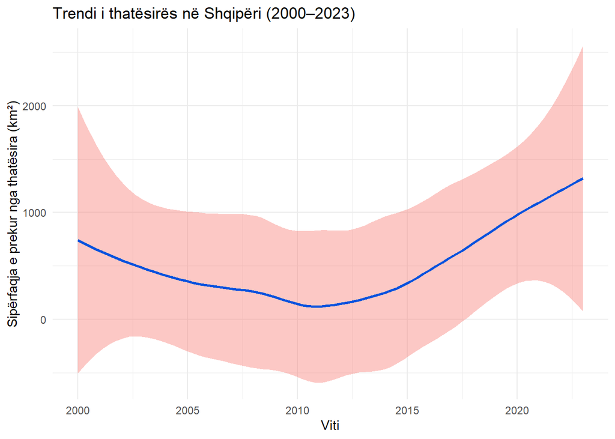

```r
Te_dhenat %>%
  filter(Shteti == "Albania") %>%
  ggplot(aes(x = Year, y = zonat_e_thatesires)) +
  geom_smooth(se = TRUE, colour = "#0452DE", fill = "#F8766D") +
  labs(
    title = "Trendi i thatësirës në Shqipëri (2000–2023)",
    x = "Viti",
    y = "Sipërfaqja e prekur nga thatësira (km²)"
  ) +
  theme_minimal()
```

```r
#Ky grafik tregon zonat e mbuluara nga thatesirat ne Shqiperi nga viti 2000-2023,vija tregon se ka pasur nje perkeqesim te situates gjate ketyre viteve e cila tregohet nga vija e lemuar e grafikut ne fjale.
```

## Histogrami i te dhenave

[figure not shown]

```r
data$time <- as.numeric(as.character(data$time))

data %>%
  filter(
    time >= 2000, time <= 2020.6,
    obs_value >= 5000, obs_value <= 650000
  ) %>%
  ggplot(aes(x = obs_value)) +
  geom_histogram(bins = 81, fill = "#112446") +
  scale_x_continuous(trans = "log") +
  labs(
    title = "Zonat e Prekura(2000–2023)",
    x = "Zonat e Prekura km²,log10",
    y = "Frekuenca")+
  theme_minimal()
```

```r
#Histogrami i treguar me siper tregon zonat e prekura nga thatesira dhe kryesisht shperndarjen e tyre nga niveli minimal deri ne nivel maximal , verehet se rrall her verehen  vlera shume te larta , duke u perqendruar kryesisht ne vjera me te vogla por me frekuenca me te larta.
```

## Asimetria e histogramit

```r
data %>%
  filter(obs_value >= 20000 & obs_value <= 650000) %>%
  summarise(asimetria = skewness(obs_value, na.rm = TRUE))
```

```
## # A tibble: 1 × 1
##   asimetria
##       <dbl>
## 1      3.28
```

```r
#Kodi i mesiperm tregon veren e Asimetrise  te te dhenave ku nje asimetri pozitive tregon se vlerat jane kryesisht te vogla , asimetri negative qe vlerat jane kryeshisht te larta dhe asimemetri te barabarte me 0 tregon se kemi shperndarje uniforme.
```

## Shtetet me te prekura nga thatesirat.

```r
summary_table <- data %>%
  filter(!is.na(obs_value)) %>%
  filter(geo_label != "European Union - 27 countries (from 2020)") %>%
  group_by(geo_label) %>%
  summarise(
    Count = n(),
    Zonat_e_Prekura = sum(obs_value)
  ) %>%
  ungroup() %>%
  mutate(
    Perqindje = round(100 * Zonat_e_Prekura / sum(Zonat_e_Prekura), 2)
  ) %>%
  arrange(desc(Perqindje))


kable(summary_table, caption = "Kontributi i çdo shteti ne totalin e zonave te prekura nga thatesira.")
```

Kontributi i çdo shteti ne totalin e zonave te prekura nga thatesira.

| geo_label | Count | Zonat_e_Prekura | Perqindje |
| --- | --- | --- | --- |
| Türkiye | 48 | 677208.16 | 13.66 |
| Spain | 48 | 613979.05 | 12.39 |
| France | 48 | 573001.92 | 11.56 |
| Germany | 48 | 324020.70 | 6.54 |
| Poland | 48 | 282391.52 | 5.70 |
| Italy | 48 | 281377.53 | 5.68 |
| Sweden | 48 | 234666.51 | 4.73 |
| Romania | 48 | 204678.79 | 4.13 |
| Finland | 48 | 182798.69 | 3.69 |
| Bulgaria | 48 | 164930.31 | 3.33 |
| Portugal | 48 | 158618.96 | 3.20 |
| Greece | 48 | 113223.57 | 2.28 |
| Norway | 48 | 108340.64 | 2.19 |
| Hungary | 48 | 93664.69 | 1.89 |
| Lithuania | 48 | 90165.70 | 1.82 |
| Bosnia and Herzegovina | 48 | 85569.78 | 1.73 |
| Serbia | 48 | 85713.19 | 1.73 |
| Czechia | 48 | 83684.93 | 1.69 |
| Croatia | 48 | 73169.91 | 1.48 |
| Austria | 48 | 72344.59 | 1.46 |
| Estonia | 48 | 67401.04 | 1.36 |
| Latvia | 48 | 67610.17 | 1.36 |
| Slovakia | 48 | 42408.33 | 0.86 |
| Belgium | 48 | 39299.08 | 0.79 |
| North Macedonia | 48 | 31933.28 | 0.64 |
| Denmark | 48 | 29247.64 | 0.59 |
| Slovenia | 48 | 27386.09 | 0.55 |
| Albania | 48 | 25455.56 | 0.51 |
| Switzerland | 48 | 24834.80 | 0.50 |
| Netherlands | 48 | 22747.93 | 0.46 |
| Iceland | 48 | 21219.88 | 0.43 |
| Montenegro | 48 | 16126.76 | 0.33 |
| Cyprus | 48 | 14607.96 | 0.29 |
| Ireland | 48 | 8457.42 | 0.17 |
| Kosovo (under United Nations Security Council Resolution 1244/99) | 48 | 8438.10 | 0.17 |
| Luxembourg | 48 | 5374.64 | 0.11 |
| Malta | 48 | 572.19 | 0.01 |
| Liechtenstein | 48 | 107.76 | 0.00 |

```r
#Tabela e dhene tregon frekuencen qe secili shtet shfaqet ne dataset e cila eshte nje vlere e barabarte per te siguruar saktesi me te larte si dhe permban vleren e kontributeve te secilit shtet ne siperfaqen totale te thate ne %.
```

## Densiteti i vlerave per disa nga vendet e europes.

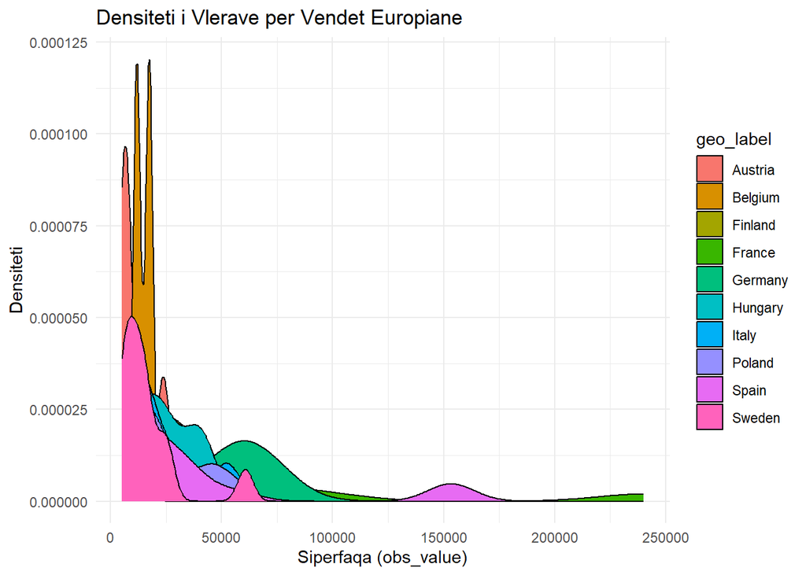

```r
data %>%
  filter(!(geo %in% c("EU27_2020", "BG", "CY", "MT", "IS",
                      "LI", "NO", "CH", "MK", "AL", "TR", "XK","BA","CZ","DK", "EE","IE","EL","HR","CY","LV","LT","LU","PT","RO","SI","SK","RS","NL"))) %>%
  filter(obs_value >= 5000L & obs_value <= 650000L) %>%
  ggplot(aes(x = obs_value, fill = geo_label)) +
  geom_density(adjust = 1L) +
  scale_y_continuous(labels =scales::comma) +
  scale_fill_hue(direction = 1) +
  theme_minimal() +
  labs(
    x = "Siperfaqa (obs_value)",
    y = "Densiteti",
    title = "Densiteti i Vlerave per Vendet Europiane"
  )
```

```r
#Ky krafik tegon dentesine per sa i perket disa vendeve europian te cilat un i kam zgjedur , mund te verehen vendet me te prekura se te tjerat bazuar ne pozicionin i cila ka secili shetet.
```